# Slowdown hypothesis

## Tadpole charts and derivatives

To start let’s just show e0 against change in e0 for all countries, just as points

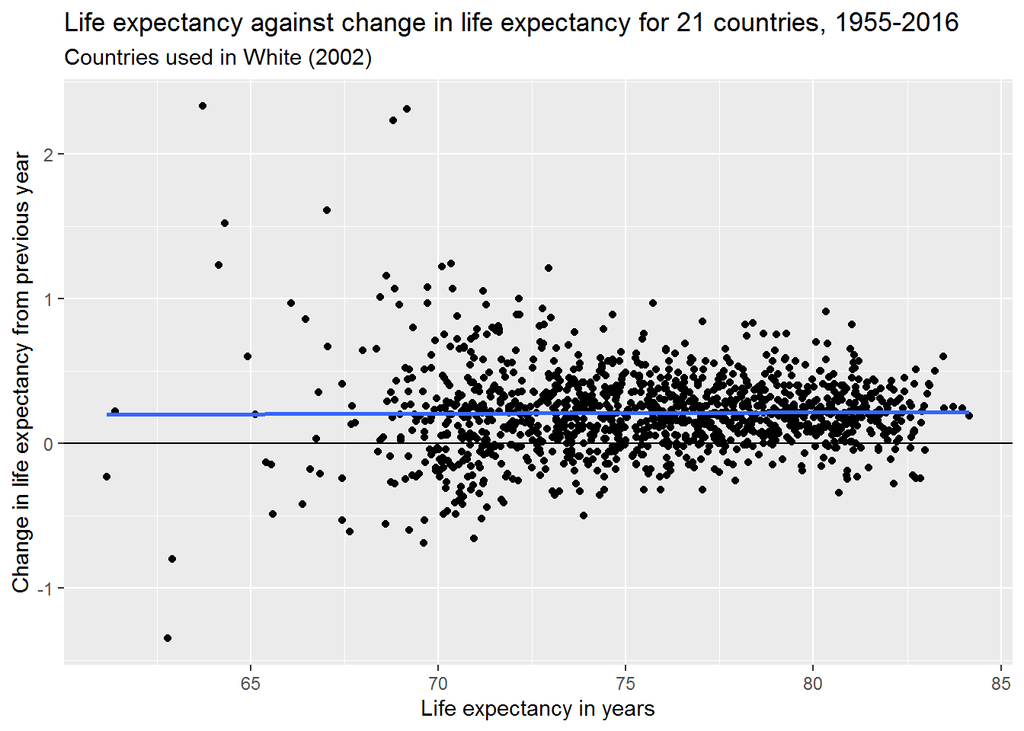

```r
dta_e0 %>%
  filter(code %in% high_income_countries) %>%
  filter(sex == "total") %>%
  filter(between(year, 1955, 2016)) %>%
  group_by(code) %>%
  arrange(year) %>%
  mutate(ch_e0 = e0 - lag(e0)) %>%
  ungroup() %>%
  ggplot(aes(x = e0, y = ch_e0)) +
  geom_point() +
  geom_hline(yintercept = 0) +
  stat_smooth(method = "lm", se = F) +
  labs(
    title = "Life expectancy against change in life expectancy for 21 countries, 1955-2016",
    subtitle = "Countries used in White (2002)",
    x = "Life expectancy in years",
    y = "Change in life expectancy from previous year"
  )
```

Here there seems to be no relationship whatsoever.

But what if there’s a Simpson’s Paradox style issue here? What do the relationships look like for each of the groups?

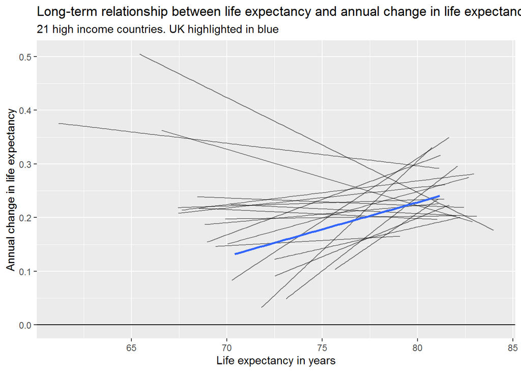

```r
tmp <- dta_e0 %>%
  filter(code %in% high_income_countries) %>%
  filter(sex == "total") %>%
  filter(between(year, 1955, 2015)) %>%
  group_by(code) %>%
  arrange(year) %>%
  mutate(ch_e0 = e0 - lag(e0)) %>%
  ungroup()

tmp %>%
  ggplot(aes(x = e0, y = ch_e0, group = code)) +
  geom_hline(yintercept = 0) +
  geom_line(
    stat = "smooth", method = "lm", se = F,
    colour = "black", alpha = 0.5) +
  stat_smooth(
    method = "lm", se = F,
    data = tmp %>% filter(code == "GBR_NP")
  ) +
  labs(
    title = "Long-term relationship between life expectancy and annual change in life expectancy",
    subtitle = "21 high income countries. UK highlighted in blue",
    x = "Life expectancy in years",
    y = "Annual change in life expectancy"
  )
```

Once again, there’s no obvious trend indicating a limit to life expectancy, and the UK is one of a number of countries where the long-term correlation between life expectancy and change in life expectancy is positive rather than negative, meaning higher life expectancies are (weakly) associated with slightly faster rates of improvement.

Perhaps this issue is confounded by the negative autocorrelation found between annual lags. To investigate this we could try the average of two years rather than a single year.

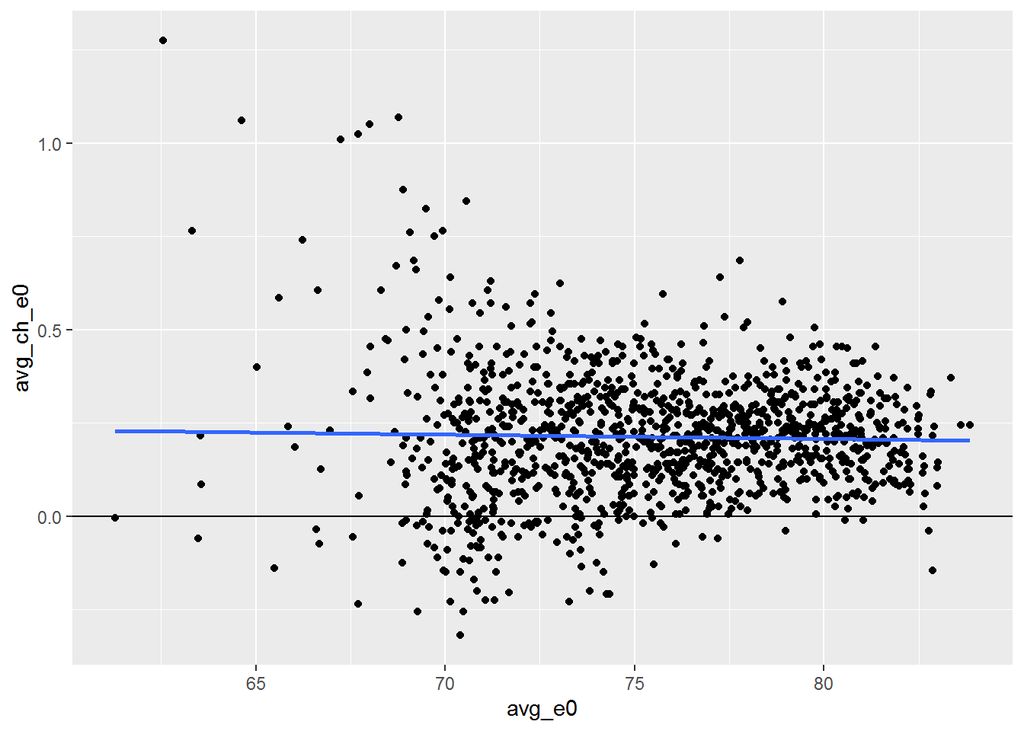

```r
dta_e0 %>%
  filter(code %in% high_income_countries) %>%
  filter(sex == "total") %>%
  filter(between(year, 1955, 2015)) %>%
  group_by(code) %>%
  arrange(year) %>%
  mutate(ch_e0 = e0 - lag(e0)) %>%
  mutate(avg_e0 = (e0 + lag(e0)) / 2) %>%
  mutate(lag_ch_e0 = lag(ch_e0)) %>%
  mutate(avg_ch_e0 = (ch_e0 + lag_ch_e0) / 2) %>%
  ungroup() %>%
  ggplot(aes(x = avg_e0, y = avg_ch_e0)) +
  geom_point() +
  geom_hline(yintercept = 0) +
  stat_smooth(method = "lm", se = F)
```

Again this makes no appreciable difference

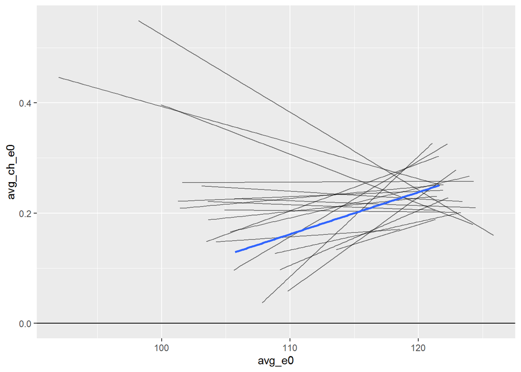

```r
tmp <- dta_e0 %>%
  filter(code %in% high_income_countries) %>%
  filter(sex == "total") %>%
  filter(between(year, 1955, 2015)) %>%
  group_by(code) %>%
  arrange(year) %>%
  mutate(ch_e0 = e0 - lag(e0)) %>%
  mutate(lag_ch_e0 = lag(ch_e0)) %>%
  mutate(avg_e0 = (e0 + lag(e0) / 2)) %>%
  mutate(avg_ch_e0 = (ch_e0 + lag_ch_e0) / 2) %>%
  ungroup()

tmp %>%
  ggplot(aes(x = avg_e0, y = avg_ch_e0, group = code)) +
  geom_hline(yintercept = 0) +
  geom_line(
    stat = "smooth", method = "lm", se = F,
    colour = "black", alpha = 0.5) +
  stat_smooth(
    method = "lm", se = F,
    data = tmp %>% filter(code == "GBR_NP")
  )
```

Again, this does not seem to make any difference.

## Table 3

To do or not bother. I think we have what we need for a short paper.

## Figure 4

Variance between life expectancies for 21 high-income countries, 1955-96

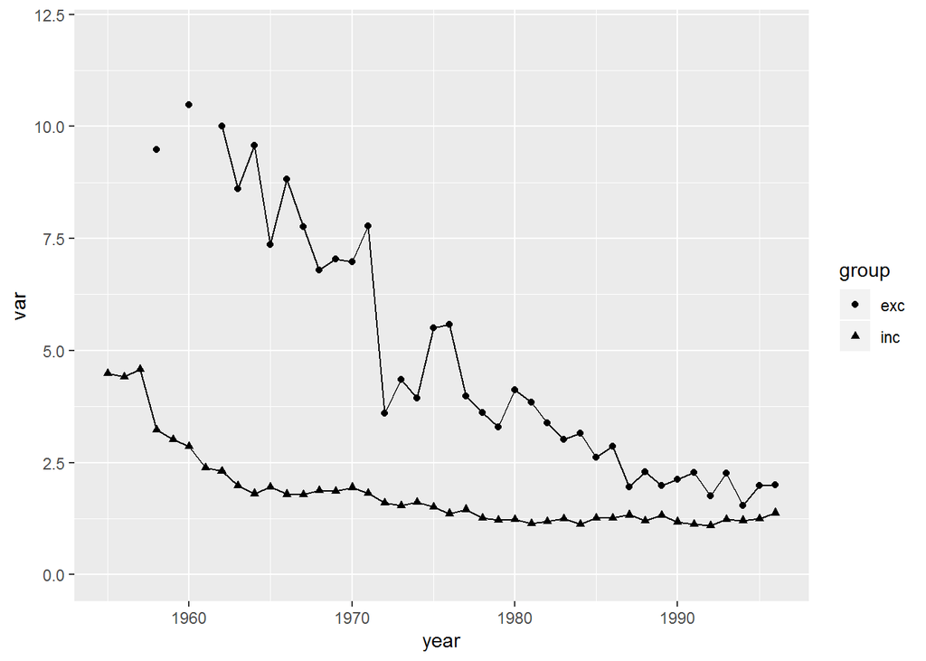

```r
dta_e0 %>%
  filter(code %in% high_income_countries) %>%
  mutate(group = ifelse(!(code %in% c("GRC", "IRL", "PRT", "ESP")), "inc", "exc")) %>%
  filter(sex == "total") %>%
  filter(between(year, 1955, 1996)) %>%
  group_by(group, year) %>%
  mutate(mean_e0 = mean(e0, na.rm = T)) %>%
  mutate(diff_from_mean = e0 - mean_e0) %>%
  summarise(var = var(diff_from_mean)) %>%
  ggplot(aes(x = year, y = var, group = group, shape = group)) +
  geom_point() + geom_line() +
  scale_y_continuous(limits = c(0, 12))
```

First question is what does this now look like?

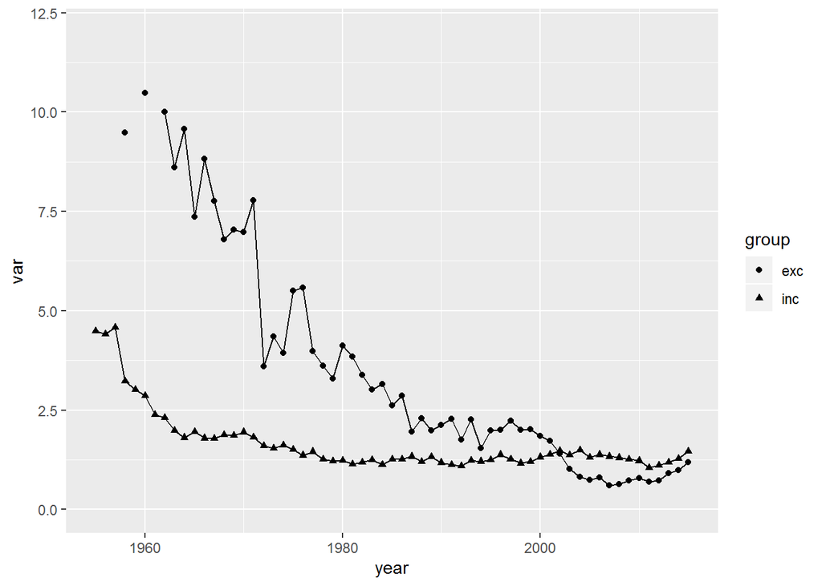

```r
dta_e0 %>%
  filter(code %in% high_income_countries) %>%
  mutate(group = ifelse(!(code %in% c("GRC", "IRL", "PRT", "ESP")), "inc", "exc")) %>%
  filter(sex == "total") %>%
  filter(between(year, 1955, 2015)) %>%
  group_by(group, year) %>%
  mutate(mean_e0 = mean(e0, na.rm = T)) %>%
  mutate(diff_from_mean = e0 - mean_e0) %>%
  summarise(var = var(diff_from_mean)) %>%
  ggplot(aes(x = year, y = var, group = group, shape = group)) +
  geom_point() + geom_line() +
  scale_y_continuous(limits = c(0, 12))
```

So, there’s been a steady increase in the variance between countries after 2010. *This is an important finding*.

Secondly, what does this look like for all countries?

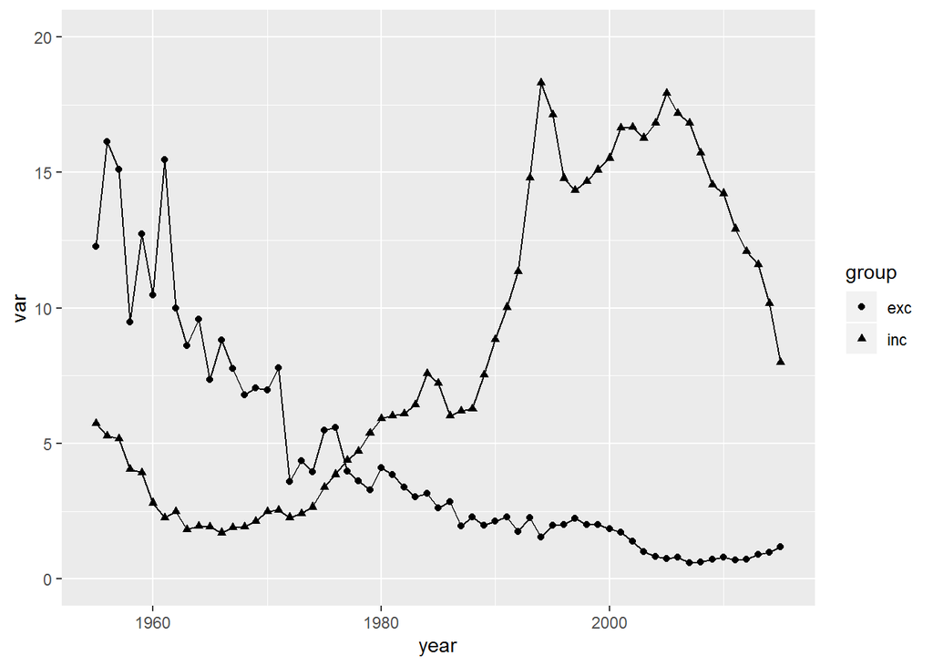

```r
dta_e0 %>%
  filter(code %in% all_distinct_countries) %>%
  mutate(group = ifelse(!(code %in% c("GRC", "IRL", "PRT", "ESP")), "inc", "exc")) %>%
  filter(sex == "total") %>%
  filter(between(year, 1955, 2015)) %>%
  group_by(group, year) %>%
  mutate(mean_e0 = mean(e0, na.rm = T)) %>%
  mutate(diff_from_mean = e0 - mean_e0) %>%
  summarise(var = var(diff_from_mean)) %>%
  ggplot(aes(x = year, y = var, group = group, shape = group)) +
  geom_point() + geom_line() +
  scale_y_continuous(limits = c(0, 20))
```

This looks to be undermined by changing population composition.

For the higher income countries in the original selection, let’s plot the difference for each individual country

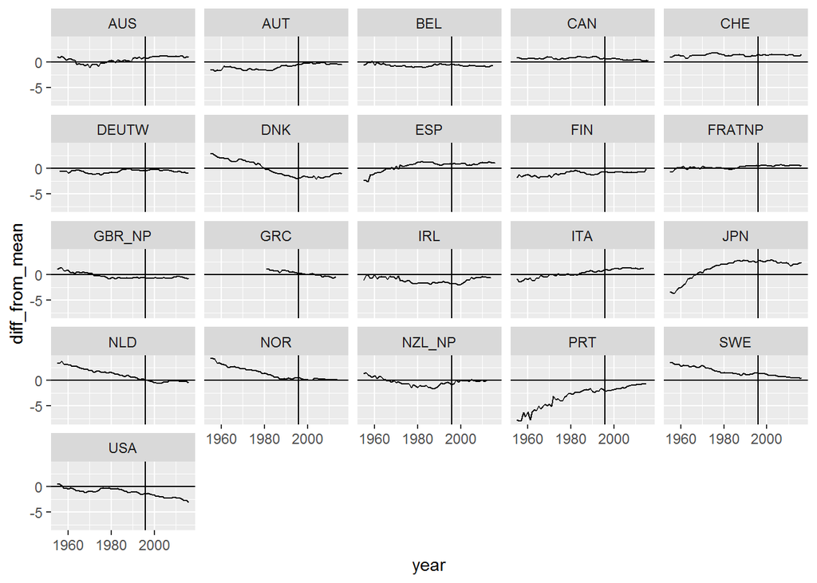

```r
dta_e0 %>%
  filter(code %in% high_income_countries) %>%
  filter(sex == "total") %>%
  filter(between(year, 1955, 2016)) %>%
  group_by(year) %>%
  mutate(mean_e0 = mean(e0, na.rm = T)) %>%
  mutate(diff_from_mean = e0 - mean_e0) %>%
  ungroup() %>%
  ggplot(aes(x = year, y = diff_from_mean)) +
  facet_wrap(~code) +
  geom_line() +
  geom_hline(yintercept = 0) +
  geom_vline(xintercept = 1996)
```

Now let’s present this all at once

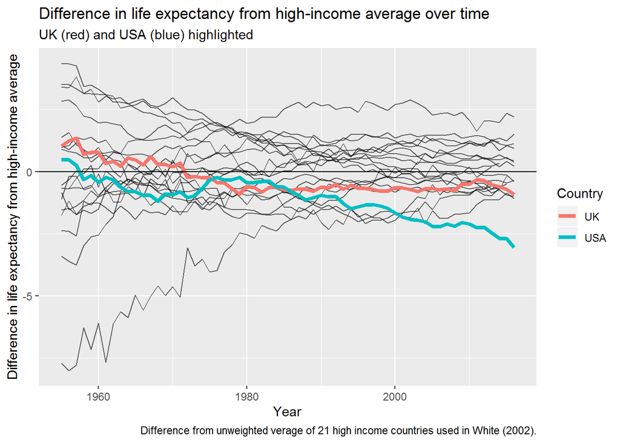

```r
tmp <- dta_e0 %>%
  filter(code %in% high_income_countries) %>%
  filter(sex == "total") %>%
  filter(between(year, 1955, 2016)) %>%
  group_by(year) %>%
  mutate(mean_e0 = mean(e0, na.rm = T)) %>%
  mutate(diff_from_mean = e0 - mean_e0) %>%
  ungroup()

tmp %>%
  ggplot(aes(x = year, y = diff_from_mean, group = code)) +
  geom_line(alpha = 0.6) +
  geom_line(aes(x = year, y = diff_from_mean, group = Country, colour = Country),
            inherit.aes = F, size = 1.5,
            data = tmp %>%
              filter(code %in% c("USA", "GBR_NP")) %>%
              mutate(Country = case_when(
                code == "USA" ~ "USA",
                code == "GBR_NP" ~ "UK"
              ))
            ) +
  geom_hline(yintercept = 0) +
  labs(
    x = "Year", y = "Difference in life expectancy from high-income average",
    title = "Difference in life expectancy from high-income average over time",
    subtitle = "UK (red) and USA (blue) highlighted",
    caption = "Difference from unweighted verage of 21 high income countries used in White (2002)."
  )
```

Both the UK and USA are distinct, but in different ways.

The USA had been declining in relative terms for many years, with a post 2010 acceleration.

Whereas the UK had been stagnating in relative terms for many years, then falling more rapidly post 2012ish.

Let’s just replicate the above for only 1997 onwards

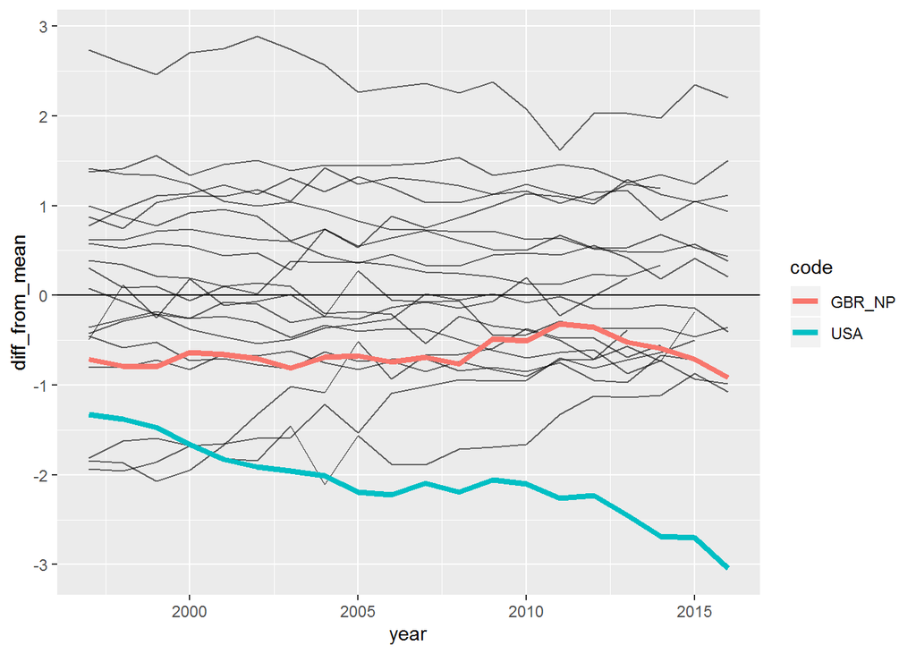

```r
tmp <- dta_e0 %>%
  filter(code %in% high_income_countries) %>%
  filter(sex == "total") %>%
  filter(between(year, 1997, 2016)) %>%
  group_by(year) %>%
  mutate(mean_e0 = mean(e0, na.rm = T)) %>%
  mutate(diff_from_mean = e0 - mean_e0) %>%
  ungroup()

tmp %>%
  ggplot(aes(x = year, y = diff_from_mean, group = code)) +
  geom_line(alpha = 0.6) +
  geom_line(aes(x = year, y = diff_from_mean, group = code, colour = code),
            inherit.aes = F, size = 1.5,
            data = tmp %>%
              filter(code %in% c("USA", "GBR_NP"))
            ) +
  geom_hline(yintercept = 0)
```

This also seems to be an important paper, as it shows how both the UK and the USA have been falling from the rich country mean more rapidly after 2012, though faster and from a lower starting point (of longer term relative decline) for the USA.

# New figures requested by Rebecca

## High income countries, side by side, original and updated period, linear regression line

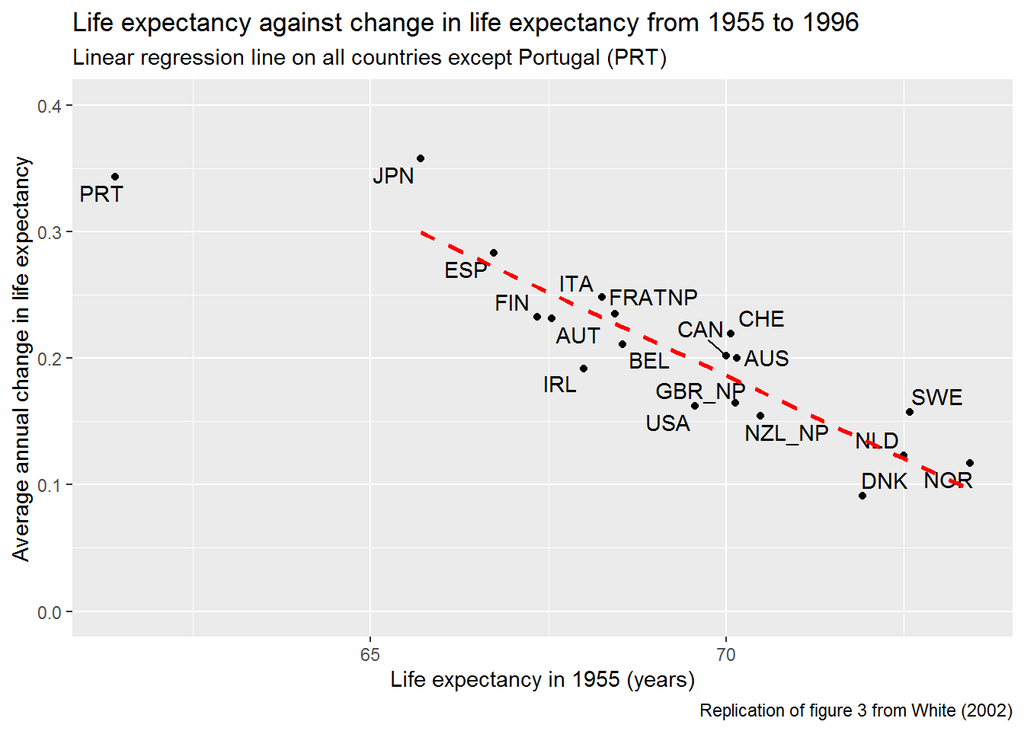

```r
dta_for_fighi_upto1996 <- dta_e0 %>%
  filter(code %in% high_income_countries) %>%
  filter(sex == "total") %>%
  filter(between(year, 1955, 1996)) %>%
  group_by(code) %>%
  arrange(year) %>%
  mutate(val_in_1955 = ifelse(1955 %in% year, e0[year == 1955], NA)) %>%
  mutate(ch_e0 = e0 - lag(e0)) %>%
  mutate(mean_ch_e0 = mean(ch_e0, na.rm = T)) %>%
  filter(year == min(year)) %>%
  ungroup() %>%
  select(code, val_in_1955, mean_ch_e0)

fig_hi_upto1996 <- dta_for_fighi_upto1996 %>%
  ggplot(aes(x = val_in_1955, y = mean_ch_e0)) +
  geom_point() +
  scale_y_continuous(limits = c(0, 0.4)) +
  ggrepel::geom_text_repel(aes(label = code)) +
  labs(
    title = "Life expectancy against change in life expectancy from 1955 to 1996",
    subtitle = "Linear regression line on all countries except Portugal (PRT)",
    x = "Life expectancy in 1955 (years)",
    y = "Average annual change in life expectancy",
    caption = "Replication of figure 3 from White (2002)"
    ) +
  stat_smooth(method = "lm", se = F, colour = "red", linetype = "dashed",
              data = dta_for_fig03 %>% filter(code != "PRT"))

print(fig_hi_upto1996)
```

[figure not shown]

```r
dta_for_fighi_upto2016 <- dta_e0 %>%
  filter(code %in% high_income_countries) %>%
  filter(sex == "total") %>%
  filter(between(year, 1955, 2016)) %>%
  group_by(code) %>%
  arrange(year) %>%
  mutate(val_in_1955 = ifelse(1955 %in% year, e0[year == 1955], NA)) %>%
  mutate(ch_e0 = e0 - lag(e0)) %>%
  mutate(mean_ch_e0 = mean(ch_e0, na.rm = T)) %>%
  filter(year == min(year)) %>%
  ungroup() %>%
  select(code, val_in_1955, mean_ch_e0)

fig_hi_upto2016 <- dta_for_fighi_upto2016 %>%
  ggplot(aes(x = val_in_1955, y = mean_ch_e0)) +
  geom_point() +
  scale_y_continuous(limits = c(0, 0.4)) +
  ggrepel::geom_text_repel(aes(label = code)) +
  labs(
    title = "Life expectancy against change in life expectancy from 1955 to 2016",
    subtitle = "Linear regression line on all countries except Portugal (PRT)",
    x = "Life expectancy in 1955 (years)",
    y = "Average annual change in life expectancy",
    caption = "Replication of figure 3 from White (2002)"
    ) +
  stat_smooth(method = "lm", se = F, colour = "red", linetype = "dashed",
              data = dta_for_fig03 %>% filter(code != "PRT"))

print(fig_hi_upto2016)
```

```r
png(filename = "figures/2x1_hi_e0_che0.png", width = 35, height = 15, res = 300, units = "cm")
gridExtra::grid.arrange(fig_hi_upto1996, fig_hi_upto2016, nrow = 1)
dev.off()
```

## All HMD countries, side by side, original and updated period, linear regression line

[figure not shown]

```r
dta_for_figall_upto1996 <- dta_e0 %>%
  filter(code %in% all_distinct_countries) %>%
  filter(sex == "total") %>%
  filter(between(year, 1955, 1996)) %>%
  group_by(code) %>%
  arrange(year) %>%
  mutate(val_in_1955 = ifelse(1955 %in% year, e0[year == 1955], NA)) %>%
  mutate(ch_e0 = e0 - lag(e0)) %>%
  mutate(mean_ch_e0 = mean(ch_e0, na.rm = T)) %>%
  filter(year == min(year)) %>%
  ungroup() %>%
  select(code, val_in_1955, mean_ch_e0)

fig_all_upto1996 <- dta_for_figall_upto1996 %>%
  ggplot(aes(x = val_in_1955, y = mean_ch_e0)) +
  geom_point() +
  scale_y_continuous(limits = c(0, 0.4)) +
  ggrepel::geom_text_repel(aes(label = code)) +
  labs(
    title = "Life expectancy against change in life expectancy from 1955 to 1996",
    subtitle = "Linear regression line on all countries except Portugal (PRT)",
    x = "Life expectancy in 1955 (years)",
    y = "Average annual change in life expectancy",
    caption = "Replication of figure 3 from White (2002) with all HMD countries"
    ) +
  stat_smooth(method = "lm", se = F, colour = "red", linetype = "dashed",
              data = dta_for_fig03 %>% filter(code != "PRT"))

print(fig_all_upto1996)
```

[figure not shown]

```r
dta_for_figall_upto2016 <- dta_e0 %>%
  filter(code %in% all_distinct_countries) %>%
  filter(sex == "total") %>%
  filter(between(year, 1955, 2016)) %>%
  group_by(code) %>%
  arrange(year) %>%
  mutate(val_in_1955 = ifelse(1955 %in% year, e0[year == 1955], NA)) %>%
  mutate(ch_e0 = e0 - lag(e0)) %>%
  mutate(mean_ch_e0 = mean(ch_e0, na.rm = T)) %>%
  filter(year == min(year)) %>%
  ungroup() %>%
  select(code, val_in_1955, mean_ch_e0)

fig_all_upto2016 <- dta_for_figall_upto2016 %>%
  ggplot(aes(x = val_in_1955, y = mean_ch_e0)) +
  geom_point() +
  scale_y_continuous(limits = c(0, 0.4)) +
  ggrepel::geom_text_repel(aes(label = code)) +
  labs(
    title = "Life expectancy against change in life expectancy from 1955 to 2016",
    subtitle = "Linear regression line on all countries except Portugal (PRT)",
    x = "Life expectancy in 1955 (years)",
    y = "Average annual change in life expectancy",
    caption = "Replication of figure 3 from White (2002) with all HMD countries"
    ) +
  stat_smooth(method = "lm", se = F, colour = "red", linetype = "dashed",
              data = dta_for_fig03 %>% filter(code != "PRT"))

print(fig_all_upto2016)
```

```r
png(filename = "figures/2x1_all_e0_che0.png", width = 35, height = 15, res = 300, units = "cm")
gridExtra::grid.arrange(fig_all_upto1996, fig_all_upto2016, nrow = 1)
dev.off()
```

## Table of High income countries, ranking by decadal period

```r
tmp <- dta_e0 %>%
  filter(code %in% high_income_countries) %>%
  filter(sex == "total") %>%
  filter(between(year, 1955, 2015)) %>%
  mutate(Decade = cut(year, seq(1955, 2015, by = 10), include.lowest = T)) %>%
  group_by(code, Decade) %>%
  arrange(year) %>%
  mutate(ch_e0 = e0 - lag(e0)) %>%
  mutate(mean_ch_e0 = mean(ch_e0, na.rm = T)) %>%
  filter(year == min(year))

lookup_table <- read_csv("https://raw.githubusercontent.com/JonMinton/hmd_explorer/master/hmd_explorer/data/country_codes_lookup.csv")
tmp %>%
  left_join(lookup_table, by = c("code"= "code")) %>%
  select(country = name, Decade, e0) %>%
  group_by(Decade) %>%
  mutate(Rank = rank(desc(e0))) %>%
  write_csv(path = "tables/e0_tables.csv")
```